# regextract usage

Nathan Heath Patterson, Vanderbilt University

October 20, 2018

## Install Cardinal and regextract

This package assumes some basic familiarity with Cardinal for IMS data analysis, including how to load and process raw data for analysis with the package. If you are unclear on these steps, see the Cardinal website : https://cardinalmsi.org

```r
#install Cardinal
source("http://bioconductor.org/biocLite.R")
biocLite("Cardinal")

#install devtools from CRAN
install.packages('devtools')

#install regextract
devtools::install_github('nhpatterson/regextract')
```

## Load required package

```r
#load regextract, this loads Cardinal as well
require(regextract)
```

## Load in example IMS data from github

```r
load(url('https://github.com/NHPatterson/random_data/raw/master/rk_gloms/ims_data/rk_peaks.RData'))
```

## Plot an ion image to see IMS canvas

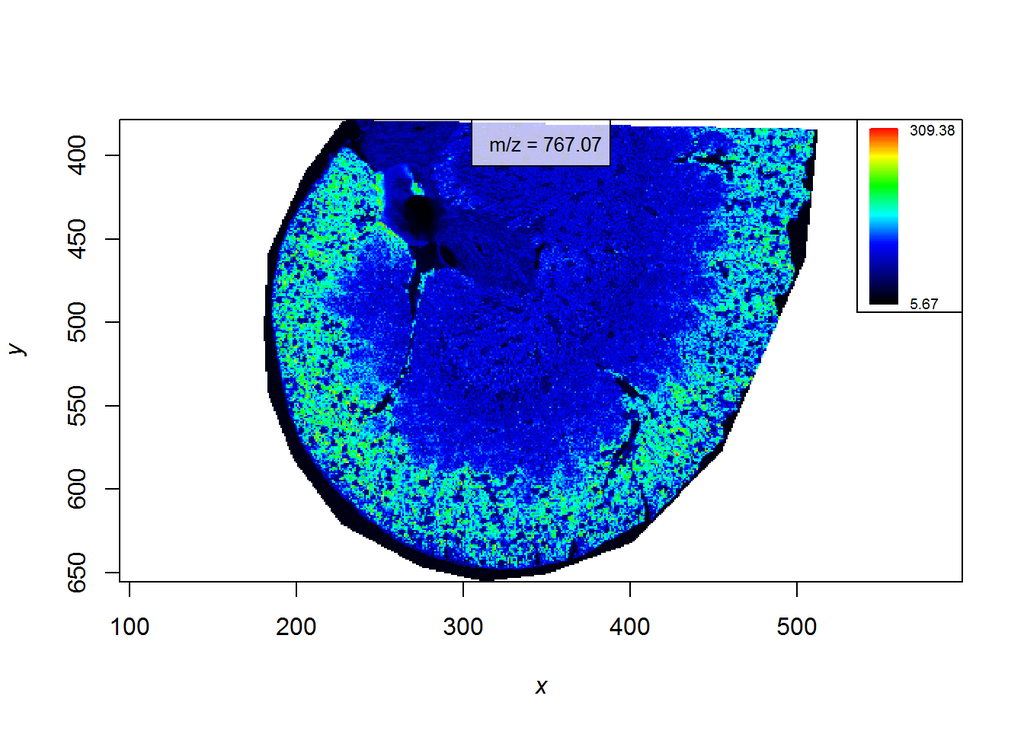

```r
image(rk_peaks, mz=766.7)
```

Note that the coordinates here start around 200 and 400 for x and y respectively. This means they are NOT minimized. Minimizes coordinates start at 1 in both x and y.

```r
rk_peaks <- reduceXYcardinal(rk_peaks)
```

## Load in the extracted ROIs key

This key is generated with the regToolboxMSRC python package (https://github.com/nhpatterson/regToolboxMSRC). Here we have annotated 10 glomeruli on the H&E image associated with this data set.

```r
gloms_key <- importSpatialCorrKey(url('https://github.com/NHPatterson/random_data/raw/master/rk_gloms/ims_data/rk_gloms_ROI_key.csv'), overlap_thresh = 0.1)
```

The names of these ROIs are set in ImageJ.

## Add ROI data to Cardinal MSImageSet

This functions returns a new Cardinal data set with the ROI metadata added to the Cardinal MSImageSet’s `featuredata`.

```r
rk_peaks_rois <- addROIfromKey(rk_peaks,
              gloms_key,
              overlap_thresh = 0.1,
              xy_min = F,
              show_images = F) #this will plot a binary image of each ROI, but can take very long, especially if there are a lot of ROIs.
```

```
## [1] "Importing ROI for : idx001_6420_2703"
## [1] "Importing ROI for : idx002_6454_2570"
## [1] "Importing ROI for : idx003_6563_2307"
## [1] "Importing ROI for : idx004_7138_3447"
## [1] "Importing ROI for : idx005_7729_4170"
## [1] "Importing ROI for : idx006_7826_4550"
## [1] "Importing ROI for : idx007_6188_2936"
## [1] "Importing ROI for : idx008_6012_2318"
## [1] "Importing ROI for : idx009_5776_2203"
## [1] "Importing ROI for : idx010_5504_2082"
```

# Do analysis on ROIs individually

The `featureApplyROIs` wraps Cardinal’s `featureApply` function for the ROIs added to the featureData using the regextract package. A data.frame where rows are ROIs and columns are intensity statistics is produced and can be saved with `write.csv` or other R table exporting functions.

```r
#here we calculate the mean for every peak in the data set for each ROI
glom_means <- featureApplyROIs(rk_peaks_rois, func='mean')

#look at resultant data.frame
print(head(glom_means)[,1:5])
```

```
##                ROI  713.948  714.998  715.998  717.049
## 1 idx001_6420_2703 14.68072 18.12704 36.72835 28.50239
## 2 idx002_6454_2570 14.96254 18.94985 32.20959 26.48219
## 3 idx003_6563_2307 15.17988 19.58913 31.81736 26.02592
## 4 idx004_7138_3447 14.51288 18.43701 34.30474 28.09688
## 5 idx005_7729_4170 14.63875 19.02392 30.12296 26.24464
## 6 idx006_7826_4550 14.89042 18.36896 31.03350 26.68434
```

As the overlap of the ROI with each pixel (between 0 and 1) is also available when using regToolboxMSRC registration, we can weight observations in our calculations by changing the featureApplyROIs function.

```r
#here we calculate the mean for every peak in the data set for each ROI
glom_weighted_means <- featureApplyROIs(rk_peaks_rois, func='weighted.means')

#look at resultant data.frame
head(glom_weighted_means)[,1:5]
```

```
##                ROI  713.948  714.998  715.998  717.049
## 1 idx001_6420_2703 14.91040 17.96034 38.20278 29.09618
## 2 idx002_6454_2570 15.07095 18.75689 33.24714 27.09167
## 3 idx003_6563_2307 15.30060 19.49378 32.70282 26.25158
## 4 idx004_7138_3447 14.59155 18.38768 36.82123 29.54146
## 5 idx005_7729_4170 14.85242 18.81831 30.89681 26.88153
## 6 idx006_7826_4550 14.82391 17.97241 31.67200 27.12795
```

Other weighted functions include: `weighted.means` `weighted.sds` `weighted.medians` `weighted.vars` `weighted.MADs`